# Ecological Niche Modeling with kuenm2

2025-02-17

# Install and Load Packages

```r
# Install package
#remotes::install_github("marlonecobos/kuenm2")

# Load packages
library(kuenm2)
library(terra)
```

# Import Data

As an example, let’s use the occurrence data provided in the package. It includes 51 occurrence records of the plant species *Myrcia hatschbachii*, derived from [Trindade & Marques (2024)](https://doi.org/10.1111/ddi.13931).

```r
# Dataframe with occurrences (longitude and latitude)
data(occ_data, package = "kuenm2") # Data example
head(occ_data)
```

```
##               species         x         y
## 1 Myrcia hatschbachii -51.29778 -29.02639
## 2 Myrcia hatschbachii -50.57861 -27.63194
## 3 Myrcia hatschbachii -49.32222 -27.81167
## 4 Myrcia hatschbachii -49.77000 -26.91000
## 5 Myrcia hatschbachii -50.21917 -28.18361
## 7 Myrcia hatschbachii -48.97908 -25.19569
```

Now, let’s visualize the occurrences:

```r
pts <- vect(occ_data, geom = c(x = "x", y = "y"), crs = "+init=epsg:4326")
plet(pts, col = "black")
```

[interactive chart not shown]

Let’s use the environmental variables provided in the package. These include four bioclimatic variables retrieved from WorldClim 2.1 and a categorical variable, soil type, retrieved from SoilGrids.

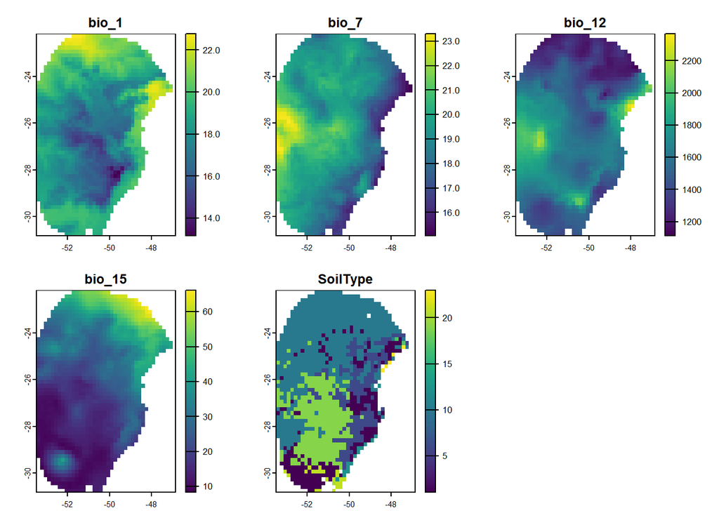

```r
# Raster with environmental variables
var <- terra::rast(system.file("extdata", "Current_variables.tif", package = "kuenm2")) # Data example
plot(var)
```

For now, let’s use only the four bioclimatic variables:

```r
# Use only continuous variables
var <- var[[1:4]]
```

# Prepare Data for Model Calibration

The first step in the package workflow is preparing data for model calibration. This includes generating background points, performing k-fold partitioning, and defining parameter combinations with varying regularization multipliers, feature classes, and environmental variable sets. Optionally, environmental variables can be converted into PCA-derived variables.

It supports both algorithms glm and maxnet. Here, we will fit maxnet models.

We will use 500 random points as background. We will create a set of candidate models by considering different combinations of variables, feature types (linear, quadratic, and product), and regularization multipliers (0.1 and 1).

```r
# Prepare data for maxnet model
sp_swd <- prepare_data(algorithm = "maxnet", occ = occ_data,
                       species = occ_data[1, 1], x = "x", y = "y",
                       raster_variables = var,
                       min_number = 3,
                       n_background = 500,
                       features = c("l", "lq", "lqp"),
                       reg_mult = c(0.1, 1))
sp_swd
```

```
## prepared_data object summary
## ==========================
## Species: Myrcia hatschbachii
## Number of occurrences: 551
##   - Number of presence points: 51
##   - Number of background points: 500
## k-Fold Cross-Validation:
##   - Number of folds: 4
## Continuous Variables:
##   - bio_1, bio_7, bio_12, bio_15
## Categorical Variables: None
## PCA Information: PCA not performed
## Weights Information: No weights provided
```

```r
# Calibration data (Sample with data - SWD)
head(sp_swd$calibration_data)
```

```
##   pr_bg    bio_1    bio_7 bio_12   bio_15
## 1     1 16.49046 18.66075   1778 12.96107
## 2     1 15.46644 19.65775   1560 14.14697
## 3     1 15.70560 17.99450   1652 23.27548
## 4     1 17.78899 19.55600   1597 18.91694
## 5     1 15.50116 18.30750   1497 15.39440
## 7     1 17.42421 17.25875   1760 34.17664
```

```r
# Candidate models
head(sp_swd$formula_grid)
```

```
##   ID                    Formulas reg_mult Features
## 1  1  ~bio_1 + bio_7 + bio_12 -1      0.1        l
## 2  2  ~bio_1 + bio_7 + bio_12 -1      1.0        l
## 3  3  ~bio_1 + bio_7 + bio_15 -1      0.1        l
## 4  4  ~bio_1 + bio_7 + bio_15 -1      1.0        l
## 5  5 ~bio_1 + bio_12 + bio_15 -1      0.1        l
## 6  6 ~bio_1 + bio_12 + bio_15 -1      1.0        l
```

```r
# Number of candidate models
nrow(sp_swd$formula_grid)
```

```
## [1] 30
```

# Explore Spatial Distribution of Occurrence and Background Points

With the `explore_calibration_geo()` function, we can explore the spatial distribution of occurrence and background points:

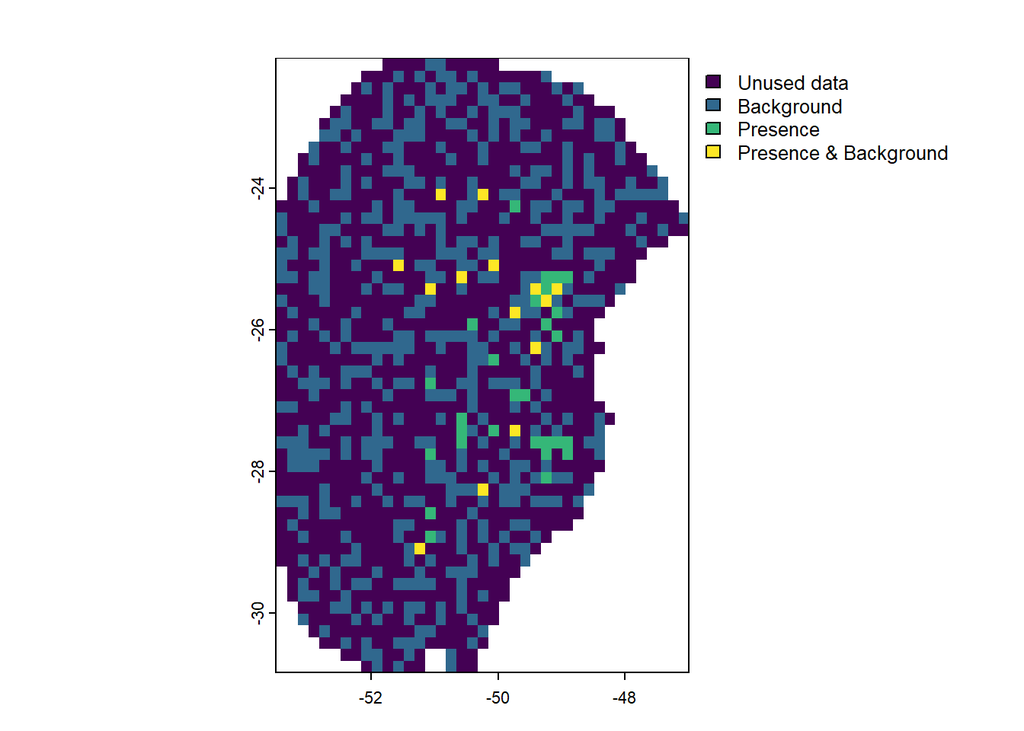

```r
pbg <- explore_calibration_geo(data = sp_swd, spat_variables = var[[1]], plot = TRUE)
```

# Explore Variable Distribution for Occurrence and Background Points

With the `explore_calibration_hist()` function, we can visualize the distribution of predictor variables for occurrence (presence) and background points.

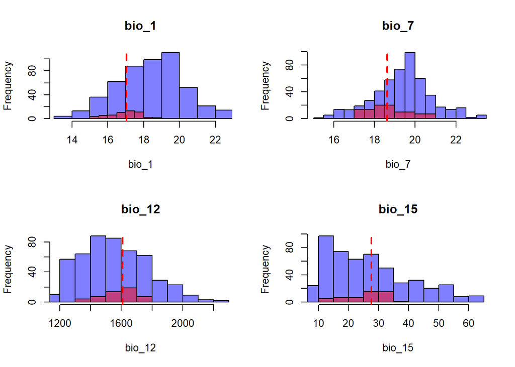

```r
explore_calibration_hist(data = sp_swd,
                         color_background = "#0000FF80",
                         color_presence = "#FF000080",
                         mfrow = c(2, 2), plot_median = TRUE,
                         breaks = "Scott")
```

# Calibrate maxnet Models

Now, we will fit and evaluate the candidate models using the data and grid of formulas prepared with prepare_data.

The function evaluate the model considering the follow metrics: - Omission rates: calculated using models trained with separate testing data subsets. Users can specify multiple omission rates to be calculated (e.g., c(5, 10)), though only one can be used as the threshold for selecting the best models. - Partial ROC: calculated following [Peterson et al. (2008)](http://dx.doi.org/10.1016/j.ecolmodel.2007.11.008). - Model complexity (AIC): assessed using models generated with the complete set of occurrences. - Unimodality (optional): Assessed through the beta coefficients of quadratic terms, following [Arias-Giraldo & Cobos (2024)](https://journals.ku.edu/jbi/article/view/21742).

In this study, we will evaluate the models considering two omission rates (5% and 10%), with model selection based on the 10% omission rate.

```r
m <- calibration(data = sp_swd, # prepare_data output
                 omission_rate = c(5, 10), # values (in %) used to calculate the omission rate.
                 omrat_threshold = 10, #Omission rate used to select the best models
                 parallel = TRUE, #To run candidate models in parallel
                 ncores = 4, #Number of cores for parallel processing
                 test_concave = TRUE, #Whether to test and remove concave curves
                 progress_bar = FALSE) #Whether to show a progress bar
```

```
## Task 1/2: checking for concave responses in models:
```

```
##
##
## Task 2/2: fitting and evaluating models with no concave responses:
```

```
##
##
## Model selection step:
```

```
## Selecting best among 30 models
```

```
## Removing 0 model(s) that failed to fit
```

```
## Removing 0 model(s) with concave responses
```

```
## Removing 0 model(s) with non-significant pROC values
```

```
## 13 models passed the 10% omission criterion
```

```
## Selecting 1 final model(s) with delta AIC <2
```

```r
m
```

```
## calibration_results object summary (maxnet)
## =============================================================
## Species: Myrcia hatschbachii
## Number of candidate models: 30
##   - Models removed because they failed to fit: 0
##   - Models removed with concave curves: 0
##   - Models removed with non-significant values of pROC: 0
##   - Models removed with omission rate > 10%: 17
##   - Models removed with delta AIC > 2: 12
## Selected models: 1
##   - Print selected models (n = 5):
##   ID                                                           Formulas
## 1 11 ~bio_1 + bio_7 + bio_12 + I(bio_1^2) + I(bio_7^2) + I(bio_12^2) -1
##   reg_mult Features Omission_rate_at_5_mean Omission_rate_at_5_sd
## 1      0.1       lq                  0.0192                0.0385
##   Mean_AUC_ratio_at_5_mean Mean_AUC_ratio_at_5_sd pval_pROC_at_5_mean
## 1                   1.5364                 0.0437                   0
##   pval_pROC_at_5_sd Omission_rate_at_10_mean Omission_rate_at_10_sd
## 1                 0                   0.0577                 0.0385
##   Mean_AUC_ratio_at_10_mean Mean_AUC_ratio_at_10_sd pval_pROC_at_10_mean
## 1                    1.5381                   0.038                    0
##   pval_pROC_at_10_sd  AIC_ws npar is_concave dAIC
## 1                  0 563.792    5      FALSE    0
```

```r
# See results for all candidate models
head(m$calibration_results$Summary)
```

[output not shown]

[output cut: 27 more lines]

```r
# See results for selected models
head(m$selected_models)
```

```
##   ID                                                           Formulas
## 1 11 ~bio_1 + bio_7 + bio_12 + I(bio_1^2) + I(bio_7^2) + I(bio_12^2) -1
##   reg_mult Features Omission_rate_at_5_mean Omission_rate_at_5_sd
## 1      0.1       lq                  0.0192                0.0385
##   Mean_AUC_ratio_at_5_mean Mean_AUC_ratio_at_5_sd pval_pROC_at_5_mean
## 1                   1.5364                 0.0437                   0
##   pval_pROC_at_5_sd Omission_rate_at_10_mean Omission_rate_at_10_sd
## 1                 0                   0.0577                 0.0385
##   Mean_AUC_ratio_at_10_mean Mean_AUC_ratio_at_10_sd pval_pROC_at_10_mean
## 1                    1.5381                   0.038                    0
##   pval_pROC_at_10_sd  AIC_ws npar is_concave dAIC
## 1                  0 563.792    5      FALSE    0
```

# Select Best Performing Models

Although the selection procedure is conducted internally during the calibration process, we can re-select models considering other omission rates (since these were calculated during calibration) and model complexity (delta AIC).

For example, let’s re-select models from the calibration results, this time considering an omission rate of 5% and a delta AIC of 10.

```r
m_10 <- sel_best_models(calibration_results = m, #calibration output
                       algorithm = "maxnet",
                       omrat_threshold = 5, # New omission rate
                       delta_aic = 10) # New Delta AIC
```

```
## Selecting best among 30 models
```

```
## Removing 0 model(s) that failed to fit
```

```
## Removing 0 model(s) with concave responses
```

```
## Removing 0 model(s) with non-significant pROC values
```

```
## 11 models passed the 5% omission criterion
```

```
## Selecting 2 final model(s) with delta AIC <10
```

```r
# Compare selected models
m$selected_models
```

```
##   ID                                                           Formulas
## 1 11 ~bio_1 + bio_7 + bio_12 + I(bio_1^2) + I(bio_7^2) + I(bio_12^2) -1
##   reg_mult Features Omission_rate_at_5_mean Omission_rate_at_5_sd
## 1      0.1       lq                  0.0192                0.0385
##   Mean_AUC_ratio_at_5_mean Mean_AUC_ratio_at_5_sd pval_pROC_at_5_mean
## 1                   1.5364                 0.0437                   0
##   pval_pROC_at_5_sd Omission_rate_at_10_mean Omission_rate_at_10_sd
## 1                 0                   0.0577                 0.0385
##   Mean_AUC_ratio_at_10_mean Mean_AUC_ratio_at_10_sd pval_pROC_at_10_mean
## 1                    1.5381                   0.038                    0
##   pval_pROC_at_10_sd  AIC_ws npar is_concave dAIC
## 1                  0 563.792    5      FALSE    0
```

```r
m_10$selected_models
```

```
##    ID
## 1  11
## 11 21
##                                                                                                          Formulas
## 1                                              ~bio_1 + bio_7 + bio_12 + I(bio_1^2) + I(bio_7^2) + I(bio_12^2) -1
## 11 ~bio_1 + bio_7 + bio_12 + I(bio_1^2) + I(bio_7^2) + I(bio_12^2) + bio_1:bio_7 + bio_1:bio_12 + bio_7:bio_12 -1
##    reg_mult Features Omission_rate_at_5_mean Omission_rate_at_5_sd
## 1       0.1       lq                  0.0192                0.0385
## 11      0.1      lqp                  0.0192                0.0385
##    Mean_AUC_ratio_at_5_mean Mean_AUC_ratio_at_5_sd pval_pROC_at_5_mean
## 1                    1.5364                 0.0437                   0
## 11                   1.5283                 0.0271                   0
##    pval_pROC_at_5_sd Omission_rate_at_10_mean Omission_rate_at_10_sd
## 1                  0                   0.0577                 0.0385
## 11                 0                   0.0577                 0.0385
##    Mean_AUC_ratio_at_10_mean Mean_AUC_ratio_at_10_sd pval_pROC_at_10_mean
## 1                     1.5381                  0.0380                    0
## 11                    1.5225                  0.0334                    0
##    pval_pROC_at_10_sd   AIC_ws npar is_concave     dAIC
## 1                   0 563.7920    5      FALSE 0.000000
## 11                  0 573.7033    7      FALSE 9.911274
```

# Fit Selected Models

After calibrating and selecting the best-performing models, we can fit the final models, which will include the consensus (mean and median) if more than one model has been selected.

```r
fm <- fit_selected(calibration_results = m, #calibration output
                   n_replicates = 4, #Number of replicates
                   rep_type = "kfold", #Replicate type
                   progress_bar = FALSE)
```

```
## Fitting replicates...
```

```
##
## Fitting full models...
```

```r
fm
```

```
## fitted_models object summary
## ==========================
## Species: Myrcia hatschbachii
## Model type: maxnet
## Number of fitted models: 1
## Models fitted with 4 replicates
```

The function also calculates the thresholds based on the omission rate used for selecting the best models

```r
# See Thresholds
fm$thresholds
```

```
## $Model_11
## $Model_11$mean
## [1] 0.4078901
##
## $Model_11$median
## [1] 0.4107328
##
##
## $consensus
## $consensus$mean
## [1] 0.4078901
##
## $consensus$median
## [1] 0.4107328
```

# Predict Models for a Single Scenario

After fitting the final models, we can predict the results. To predict the results for a single environmental scenario, we use the predict_selected() function

```r
p <- predict_selected(models = fm, #fit_selected output
                      raster_variables = var, # SpatRaster of variables for predicting
                      consensus_per_model = TRUE, #compute consensus for each model across its replicates
                      consensus_general = TRUE, #compute a general consensus across all models
                      consensus = c("median", "range", "mean", "stdev"),
                      clamping = FALSE,
                      var_to_clamp = NULL,
                      type = "cloglog",
                      progress_bar = FALSE)
```

The output of the function is a list of spatRaster objects containing the results for the individual selected models and the consensus:

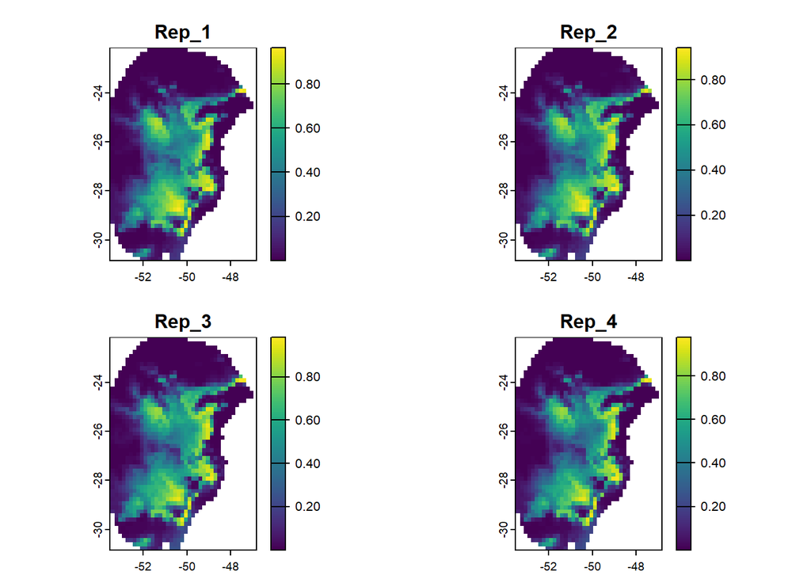

```r
# Plot replicates
plot(p[[1]]$Replicates)
```

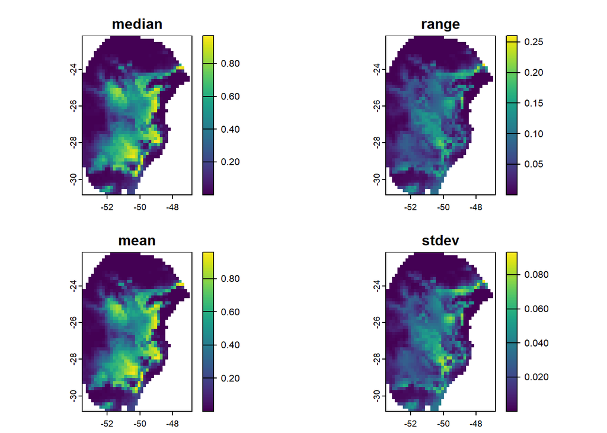

```r
# Plot consensus between replicates
plot(p[[1]]$Model_consensus)
```

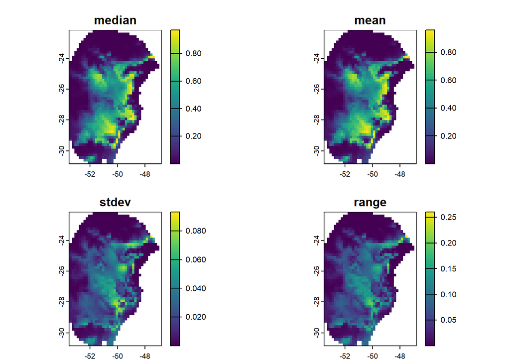

```r
# Plot consensus between models
plot(p$General_consensus)
```

# Variable Response Curves

The response curves of the model can be visualized using the `response_curve()` function:

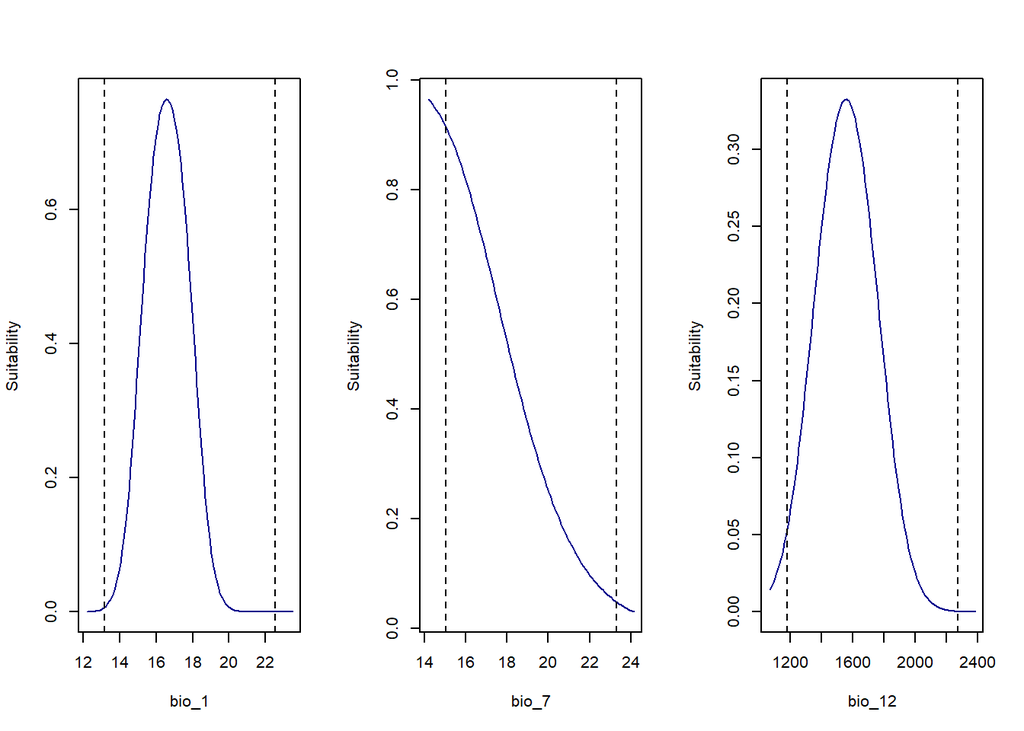

```r
par(mfrow = c(1,3))
response_curve(models = fm, variable = "bio_1")
response_curve(models = fm, variable = "bio_7")
response_curve(models = fm, variable = "bio_12")
```

```r
par(mfrow = c(1,1))
```

# Two-Way interaction response plot

In this case, we don’t have a selected model with products. Let’s use an example from the package to display a 2-way interaction plot.

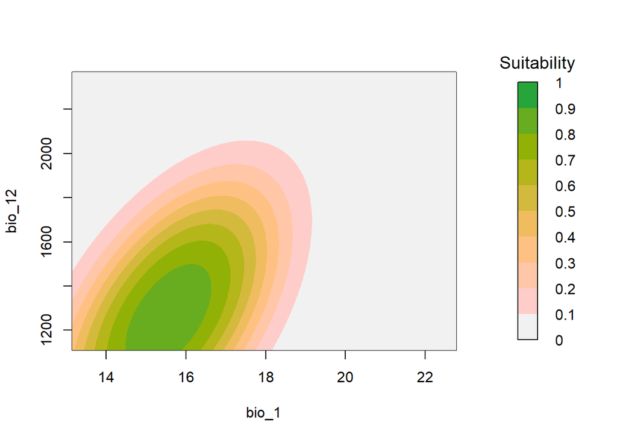

```r
# Import example of fitted_models (output of fit_selected())
data("fitted_model_glmnet", package = "kuenm2")

#Response curves (products)
resp2var(models = fitted_model_glmnet, modelID = "Model_13",
         variable1 = "bio_1", variable2 = "bio_12")
```

# Variable importance

We can use the `var_importance()` function to evaluate the relative contribution of each variable:

```r
imp_maxnet <- var_importance(models = fm, progress_bar = FALSE)
```

```
##
## Calculating variable contribution for model 1 of 1
```

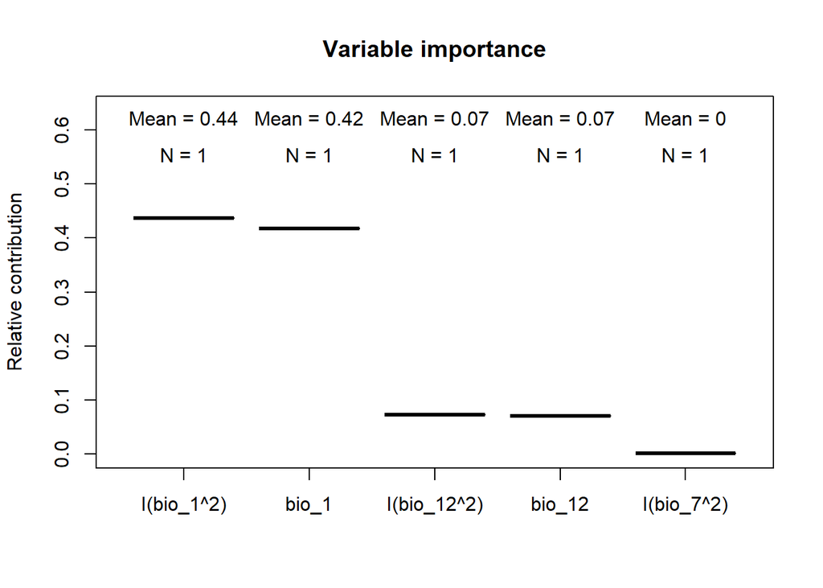

```r
# Plot using enmpa package
enmpa::plot_importance(imp_maxnet)
```

# Organize Future Climate Variables

The package includes a set of functions that facilitate the projection for multiple scenarios at once, from organizing the files into the correct folders to identifying consensus across multiple GCMs.

The `organize_future_worldclim()` function imports future climate variables downloaded from WorldClim, renames the files, and organizes them into folders categorized by year, scenario (SSP) and General Circulation Model (GCM).

This function simplifies climate data preparation, making it compatible with the prepare_proj() function and ensuring that all required variables are properly structured for modeling projections

Before using the function, download and save the future climate variables from WorldClim in a single folder. Here, we will use the variables included in the package as an example.

```r
in_dir <- system.file("extdata", package = "kuenm2")
list.files(in_dir)
```

```
## [1] "Current_variables.tif"
## [2] "wc2.1_10m_bioc_ACCESS-CM2_ssp126_2041-2060.tif"
## [3] "wc2.1_10m_bioc_ACCESS-CM2_ssp126_2081-2100.tif"
## [4] "wc2.1_10m_bioc_ACCESS-CM2_ssp585_2041-2060.tif"
## [5] "wc2.1_10m_bioc_ACCESS-CM2_ssp585_2081-2100.tif"
## [6] "wc2.1_10m_bioc_MIROC6_ssp126_2041-2060.tif"
## [7] "wc2.1_10m_bioc_MIROC6_ssp126_2081-2100.tif"
## [8] "wc2.1_10m_bioc_MIROC6_ssp585_2041-2060.tif"
## [9] "wc2.1_10m_bioc_MIROC6_ssp585_2081-2100.tif"
```

Let’s create a folder called Future_variables to save the variables, organized by year, scenario (SSP), and General Circulation Model (GCM):

```r
out_dir_future <- file.path("Future_variables")
dir.create(out_dir_future)
organize_future_worldclim(input_dir = in_dir,
                          output_dir = out_dir_future,
                          name_format = "bio_",
                          variables = NULL,
                          fixed_variables = NULL,
                          mask = NULL,
                          overwrite = TRUE,
                          progress_bar = FALSE)
```

```
##
## Variables successfully organized in the root directory:
##  Future_variables
```

Let’s see the structure of the folders with the variables for projection:

```r
list.files("Future_variables", recursive = T)
```

```
## [1] "2041-2060/ssp126/ACCESS-CM2/Variables.tiff"
## [2] "2041-2060/ssp126/MIROC6/Variables.tiff"
## [3] "2041-2060/ssp585/ACCESS-CM2/Variables.tiff"
## [4] "2041-2060/ssp585/MIROC6/Variables.tiff"
## [5] "2081-2100/ssp126/ACCESS-CM2/Variables.tiff"
## [6] "2081-2100/ssp126/MIROC6/Variables.tiff"
## [7] "2081-2100/ssp585/ACCESS-CM2/Variables.tiff"
## [8] "2081-2100/ssp585/MIROC6/Variables.tiff"
```

With the variables structured, we can prepared data for model projections to multiple scenarios.

# Prepare Data for Model Projections

The `prepare_proj()` function prepares data for model projections across multiple scenarios, storing the paths to the rasters that represent each scenario.

First, however, we need to save the current variables used to fit the model in a specific folder

```r
out_dir_current <- "Current_raw"
dir.create(out_dir_current)
#Save variables in the Current_raw folder
writeRaster(var, file.path(out_dir_current, "Variables.tif"), overwrite = T)
```

Now, we can prepare the data for projection. We need to specify the time periods (here, 2041-2060 and 2081-2100), the emission scenarios (here, ssp126 and ssp585), and the GCMs (here, ACCESS-CM2 and MIROC6)

```r
pr <- prepare_proj(models = fm,
                   present_dir = out_dir_current,
                   past_dir = NULL,
                   future_dir = out_dir_future,
                   future_period = c("2041-2060", "2081-2100"),
                   future_pscen = c("ssp126", "ssp585"),
                   future_gcm = c("ACCESS-CM2", "MIROC6"),
                   write_file = FALSE,
                   filename = NULL,
                   raster_pattern = ".tif*")
pr
```

```
## projection_data object summary
## =============================
## Variables prepared to project models for Present and Future
## Future projections contain the following periods, scenarios and GCMs:
##   - Periods: 2041-2060 | 2081-2100
##   - Scenarios: ssp126 | ssp585
##   - GCMs: ACCESS-CM2 | MIROC6
## All variables are located in the following root directory:
## C:/Users/wever/Desktop/GitHub/Curso_Fiocruz
```

# Project selected models for multiple scenarios

Now, we can predict the selected models across the multiple scenarios specified in the prepare_proj() function. In addition to generating predictions for each replicate, the function calculates consensus measures (e.g., mean, median) across both replicates and models.

```r
#Create folder to save projection results
out_dir <- file.path("Projection_results/maxnet")
dir.create(out_dir, recursive = TRUE)
p <- project_selected(models = fm,
                      projection_data = pr,
                      out_dir = out_dir,
                      consensus_per_model = TRUE,
                      consensus_general = TRUE,
                      consensus = c("median", "range", "mean", "stdev"),
                      write_replicates = TRUE,
                      clamping = FALSE,
                      var_to_clamp = NULL,
                      type = "cloglog",
                      overwrite = TRUE,
                      parallel = FALSE,
                      ncores = 1,
                      parallelType = "doSNOW",
                      progress_bar = FALSE,
                      verbose = TRUE)
p
```

```
## model_projections object summary
## ================================
## Models projected for Present and Future
## Future projections contain the following periods, scenarios and GCMs:
##   - Periods: 2041-2060 | 2081-2100
##   - Scenarios: ssp126 | ssp585
##   - GCMs: ACCESS-CM2 | MIROC6
## All raster files containing the projection results are located in the following root directory:
##  C:/Users/wever/Desktop/GitHub/Curso_Fiocruz/Projection_results/maxnet
```

Let’s check the files and import some results:

```r
#See files
list.files(out_dir, recursive = TRUE)[1:5]
```

[output not shown]

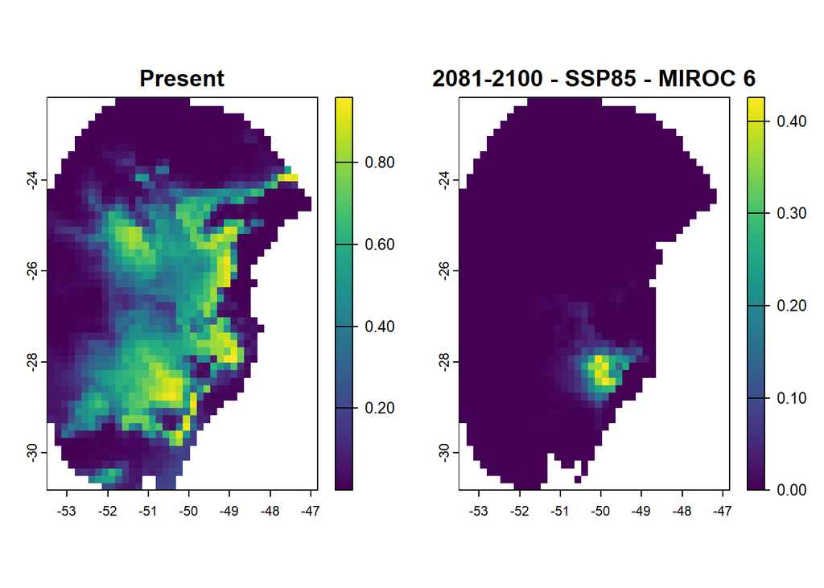

```r
#Import some projection
res_present <- rast("Projection_results/maxnet/Present/Present/General_consensus.tiff")
res_future <- rast("Projection_results/maxnet/Future/2081-2100/ssp585/MIROC6/General_consensus.tiff")
par(mfrow = c(1,2))
plot(res_present$mean, main = "Present")
plot(res_future$mean, main = "2081-2100 - SSP85 - MIROC 6")
```

# Compute Areas of Change

The interpretation of predictions for multiple scenarios and GCMs can be straightforward. With the proj_changes() function, we can calculate the level of agreement among all GCMs for each emission scenario, focusing on how and where the projected models change over time compared to the current model. The changes include loss (contraction), gain (expansion), and stability:

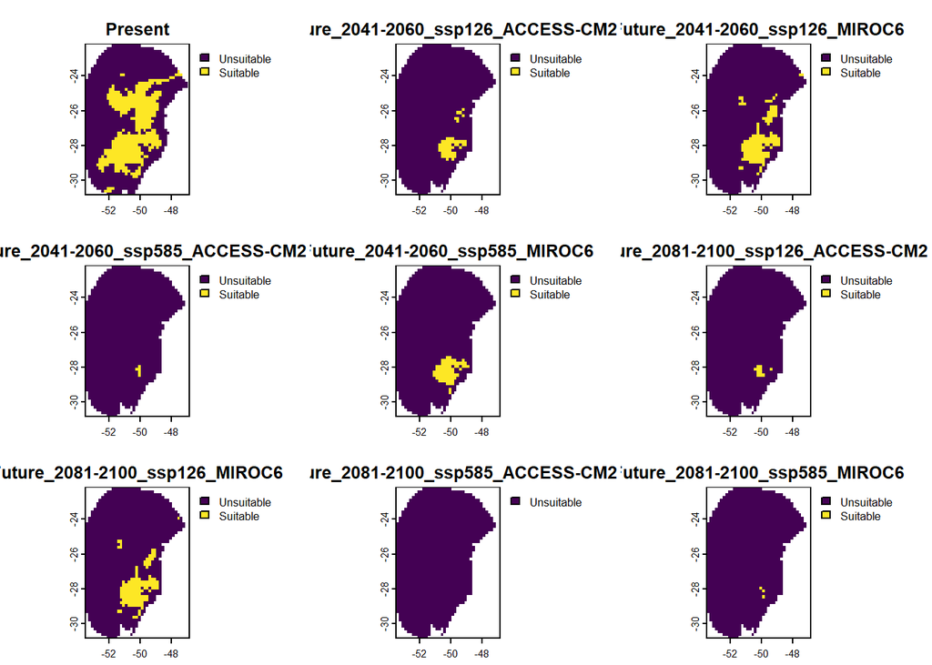

```r
changes <- proj_changes(model_projections = p,
                        reference_id = 1,
                        consensus = "mean",
                        by_gcm = TRUE,
                        by_change = TRUE,
                        general_summary = TRUE,
                        force_resample = TRUE,
                        write_results = FALSE,
                        output_dir = NULL,
                        overwrite = FALSE,
                        return_rasters = TRUE)

#See results
plot(changes$Binarized) #SpatRaster with the binarized models for each GCM
```

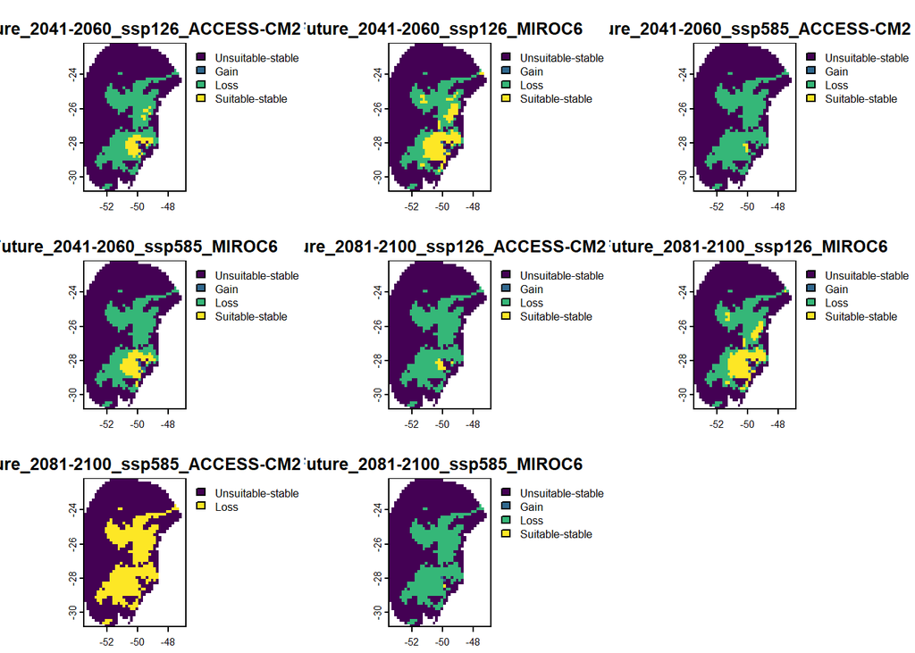

```r
plot(changes$Results_by_gcm) #SpatRaster with the computed changes for each GCM
```

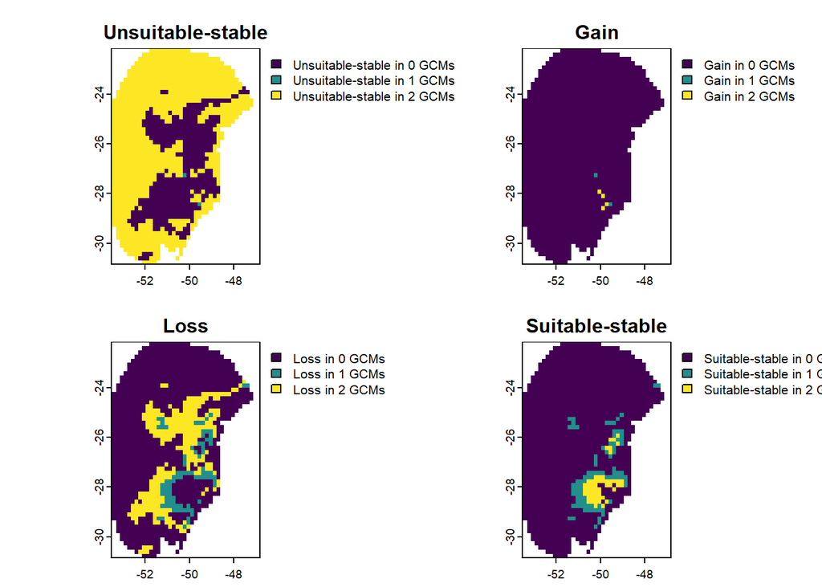

```r
plot(changes$Results_by_change$`Future_2041-2060_ssp126`) #List containing the SpatRaster with each computed change for each GCM
```

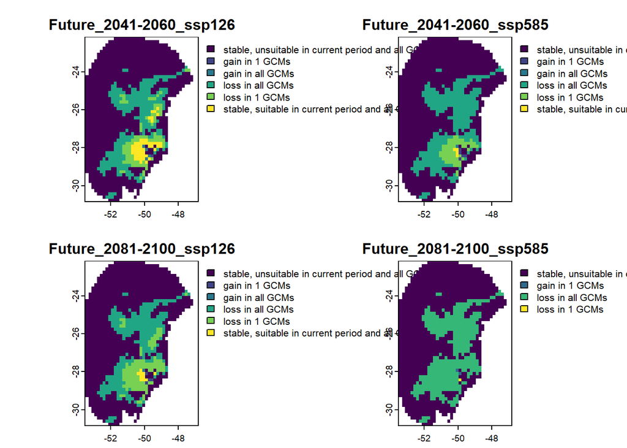

```r
plot(changes$Summary_changes) #SpatRaster with the general summary
```

# Prediction variance coming from distinct sources

With the `modvar()` function, we can calculate the variance in model predictions, distinguishing between different sources of variation, including replicates, model parameterizations, and general circulation models (GCMs)

```r
v <- modvar(model_projections = p,
            by_replicate = T,
            by_gcm = TRUE,
            by_model = TRUE,
            consensus = "median",
            write_files = FALSE,
            output_dir = NULL,
            return_rasters = TRUE,
            progress_bar = FALSE,
            verbose = TRUE,
            overwrite = FALSE)
```

```
##
## Calculating prediction variance coming from distinct replicates: scenario 1 of 5
```

```
## Calculating prediction variance coming from distinct models: scenario 1 of 5
```

```
##
## Calculating prediction variance coming from distinct replicates: scenario 2 of 5
```

```
## Calculating prediction variance coming from distinct models: scenario 2 of 5
```

```
## Calculating prediction variance coming from distinct GCMs: scenario 2 of 5
```

```
##
## Calculating prediction variance coming from distinct replicates: scenario 3 of 5
```

```
## Calculating prediction variance coming from distinct models: scenario 3 of 5
```

```
## Calculating prediction variance coming from distinct GCMs: scenario 3 of 5
```

```
##
## Calculating prediction variance coming from distinct replicates: scenario 4 of 5
```

```
## Calculating prediction variance coming from distinct models: scenario 4 of 5
```

```
## Calculating prediction variance coming from distinct GCMs: scenario 4 of 5
```

```
##
## Calculating prediction variance coming from distinct replicates: scenario 5 of 5
```

```
## Calculating prediction variance coming from distinct models: scenario 5 of 5
```

```
## Calculating prediction variance coming from distinct GCMs: scenario 5 of 5
```

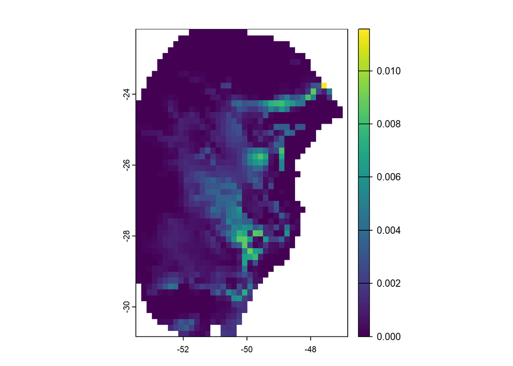

```r
#Plot some results
plot(v$Present$by_rep) #Variance coming from replicates in Present projection
```

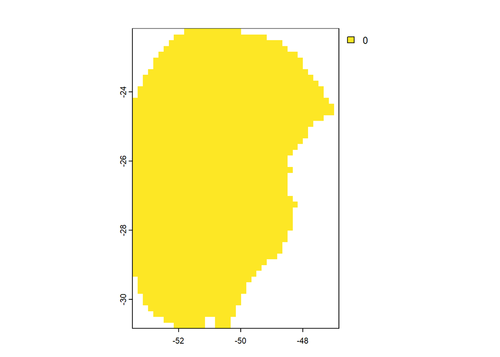

```r
plot(v$Present$by_model) #Variance coming from models in Present projection
```

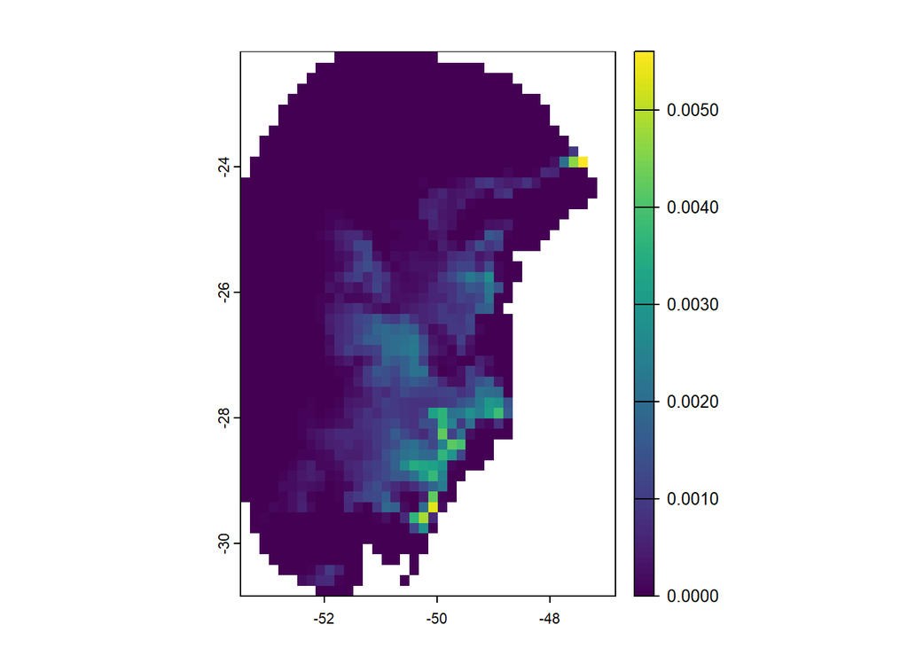

```r
plot(v$`Future_2041-2060_ssp126`$by_rep) #Variance coming from replicates in one of the future projections
```

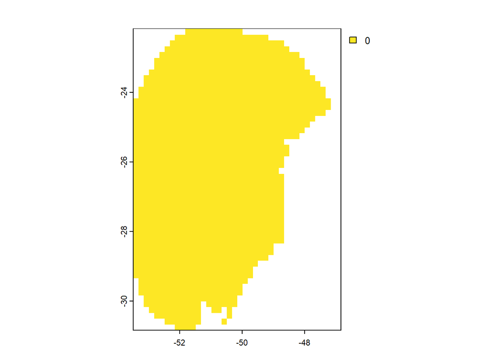

```r
plot(v$`Future_2041-2060_ssp126`$by_model) #Variance coming from models in one of the future projections
```

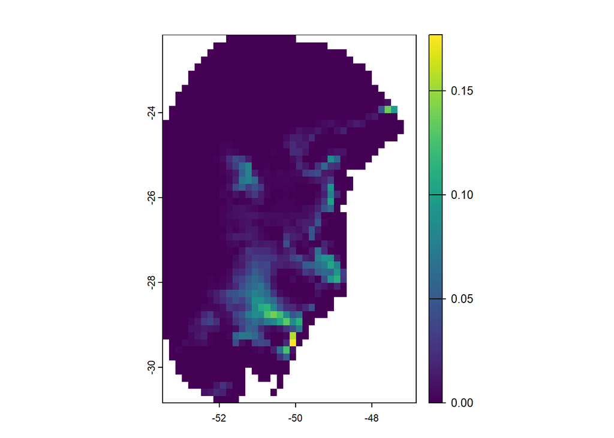

```r
plot(v$`Future_2041-2060_ssp126`$by_gcm) #Variance coming from GCMs in one of the future projections
```

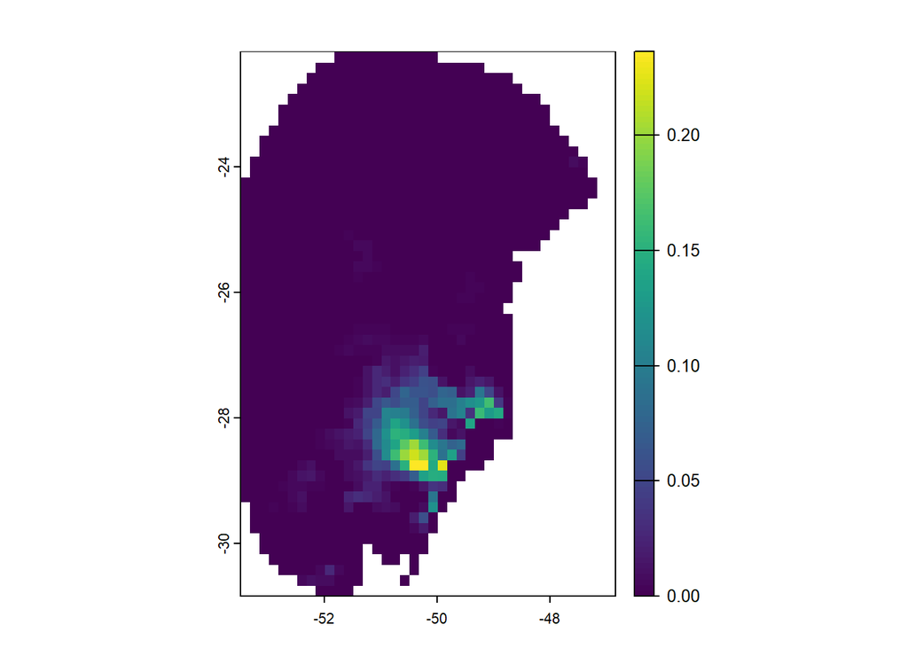

```r
plot(v$`Future_2041-2060_ssp585`$by_gcm) #Variance coming from GCMs in one of the future projections
```

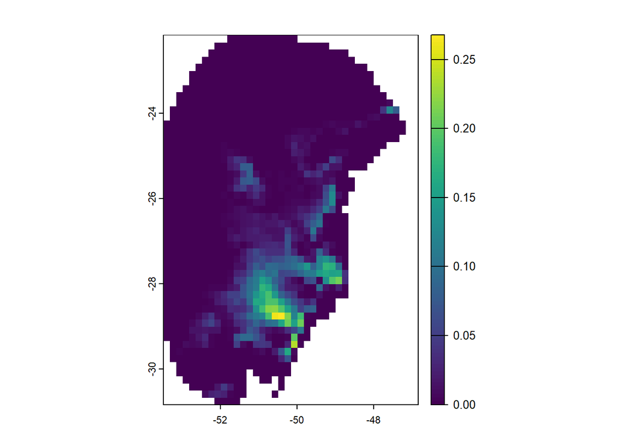

```r
plot(v$`Future_2081-2100_ssp126`$by_gcm) #Variance coming from GCMs in one of the future projections
```

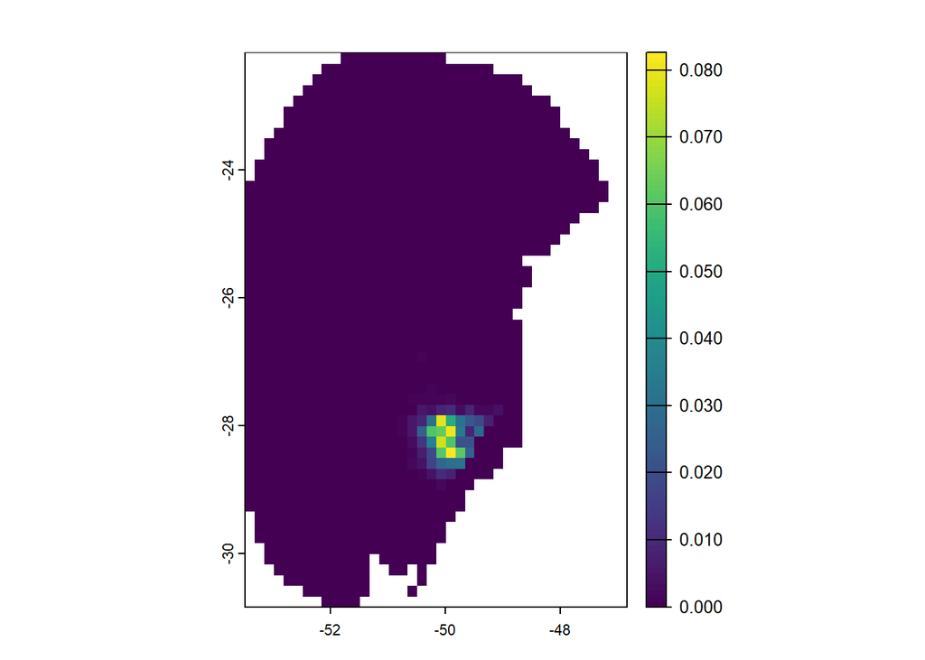

```r
plot(v$`Future_2081-2100_ssp585`$by_gcm) #Variance coming from GCMs in one of the future projections
```

# Analyze Extrapolation Risks Using MOP Metric

To identify non-analogous conditions in the projected areas when compared to the calibration area, we can perform an analysis of extrapolation risks using the mobility-oriented parity metric (MOP):

```r
out_dir <- file.path("MOP_results")
dir.create(out_dir, recursive = TRUE)
kmop <- kuenm_mop(data = sp_swd,
                  subset_variables = TRUE,
                  mask = NULL,
                  fitted_models = fm,
                  projection_data = pr,
                  out_dir = out_dir,
                  type = "detailed",
                  progress_bar = FALSE,
                  overwrite = TRUE)
```

Let’s plot some results. The simple MOP shows the number of variables with non-analogous conditions across the projected scenario:

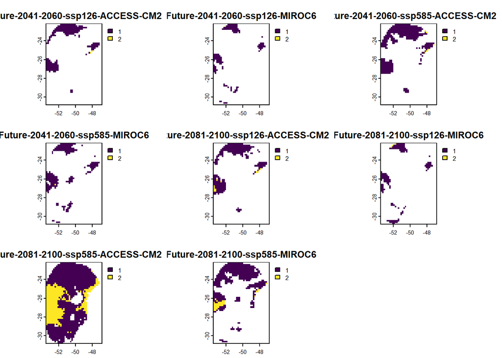

```r
#Import simple mop
simple_mop_files <- list.files("MOP_results/Future/",
                               recursive = TRUE, full.names = TRUE,
                               pattern = "simple")
#Remove aux files
simple_mop_files <- simple_mop_files[!grepl("aux", simple_mop_files)]
#Read rasters
simple_mop <- rast(simple_mop_files)
#Rename rasters
names(simple_mop) <- sub("\\_mopsimple.tif$", "", gsub("/", "-",
                                              sub(".*MOP_results/", "", simple_mop_files)))
#Plot
plot(simple_mop)
```

A more detailed view of the non-analogous conditions can be obtained by examining the combinations of variables that exhibit non-analogous conditions at both the low and high ends of the variable range:

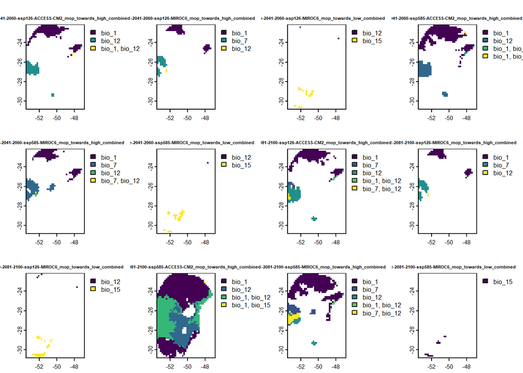

```r
#Import detailed mop
detailed_mop_files <- list.files("MOP_results/Future/",
                               recursive = TRUE, full.names = TRUE,
                               pattern = "combined")
#Remove aux and csv files
detailed_mop_files <- detailed_mop_files[!grepl("aux|csv", detailed_mop_files)]
#Read rasters
detailed_mop <- rast(detailed_mop_files)
#Rename rasters
names(detailed_mop) <- sub("\\.tif$", "", gsub("/", "-",
                           sub(".*MOP_results/", "", detailed_mop_files)))
#Remove results with NA
na_results <- sapply(detailed_mop, function(x) !is.na(minmax(x)[1]))
detailed_mop <- detailed_mop[[na_results]]
#Plot first 8 mop results
plot(detailed_mop, cex.main= 0.5)
```